# Interaction (Effect Modification) in Regression

CRP 241 Tutorial

Author

Duke University Clinical Research Training Program

Published

November 5, 2025

# Introduction

**Learning Objectives**

After completing this tutorial, you will be able to:

- **Define** interaction (effect modification) in regression
- **Recognize** when an effect differs across subgroups
- **Use** regression with interaction terms to test for effect modification
- **Interpret** stratified analyses and visualizations
- **Apply** clinical reasoning to determine if interactions are meaningful

## 0.1 What is Interaction (Effect Modification)?

**Interaction** (also called **effect modification**) occurs when the effect of one variable on an outcome depends on the level of another variable.

**Key Concept**

In simple terms: “Does the relationship between X and Y differ across levels of Z?”

**Example:** Does the effect of smoking on lung function differ by age?

- If younger patients show a small smoking effect but older patients show a large smoking effect, then **age modifies** the smoking effect.
- We say there is **interaction** between smoking and age.

## 0.2 Why Interaction Matters Clinically

**Clinical Relevance**

Interactions help us:

- **Personalize treatment:** Identify which patients benefit most (or least) from an intervention
- **Understand mechanisms:** Discover biological or behavioral factors that amplify or reduce effects
- **Avoid misleading conclusions:** A pooled (average) effect may hide important subgroup differences

**Example:** A drug may be highly effective in younger patients but ineffective (or even harmful) in older patients. Reporting only the average effect across all ages would be misleading.

## 0.3 How to Detect Interaction

**Statistical Approaches**

1. **Stratified analysis:** Fit separate models within each subgroup and compare the effect estimates
2. **Regression with interaction term:** Include a product term (e.g., X × Z) in the model; test if the coefficient is significant
3. **Visual inspection:** Plot the relationship for each subgroup; look for different slopes or patterns

**Key point:** A statistically significant interaction term (p < 0.05) provides evidence that the effect differs across subgroups.

# 1 Example 1: FEV1 and Smoking in COPD Patients

## 1.1 Study Background

A study examined whether smoking status (current/recent/former vs non-smoker) is associated with FEV1 (forced expiratory volume in one second, a measure of lung function) in patients with COPD. Age (≥65 vs <65 years) was also recorded.

- **Sample:** 200 patients randomly selected from a clinical practice
- **Exposure:** Smoking status (1 = current/recent/former smoker; 0 = non-smoker)
- **Outcome:** FEV1 (liters)
- **Potential effect modifier:** Age (1 = ≥65 years; 0 = <65 years)

**Clinical Question**

Does the effect of smoking on lung function differ by age? We expect smokers to have lower FEV1, but is this effect stronger in older or younger COPD patients?

## 1.2 Data Dictionary

FEV1 Study Variables

| Variable | Description | Coding |
| --- | --- | --- |
| `FEV1` | Forced expiratory volume in 1 second | Liters (continuous); higher = better |
| `SMOKING` | Patient smoking status | 1 = Current/recent/former smoker; 0 = Non-smoker |
| `AGE65` | Patient age group | 1 = Age ≥65 years; 0 = Age <65 years |

## 1.3 Loading and Examining the Data

```r
# Load the FEV1 smoking dataset
load(url("https://www.duke.edu/~sgrambow/crp241data/fev1_smoking.RData"))

# Examine structure
str(fsdata)
```

```
'data.frame':   200 obs. of  3 variables:
 $ FEV1   : num  2.66 4.22 4.8 2.21 3.29 ...
 $ SMOKING: num  0 0 0 0 0 0 0 0 0 0 ...
 $ AGE65  : int  0 1 0 1 0 1 0 1 0 1 ...
```

```r
# Summary statistics
summary(fsdata)
```

```
      FEV1          SMOKING        AGE65
 Min.   :1.335   Min.   :0.0   Min.   :0.0
 1st Qu.:2.760   1st Qu.:0.0   1st Qu.:0.0
 Median :3.569   Median :0.5   Median :0.5
 Mean   :3.577   Mean   :0.5   Mean   :0.5
 3rd Qu.:4.188   3rd Qu.:1.0   3rd Qu.:1.0
 Max.   :6.280   Max.   :1.0   Max.   :1.0
```

**Quick Check**

- 200 observations
- FEV1 is continuous (liters)
- SMOKING and AGE65 are binary (0/1)
- No missing values (if all variables show 200 obs)

```r
# Create subsets by age group for stratified analyses
old   <- subset(fsdata, AGE65 == 1)
young <- subset(fsdata, AGE65 == 0)
```

## 1.4 Exploratory Summaries

```r
# FEV1 by age group
by(fsdata$FEV1, fsdata$AGE65, summary)
```

```
fsdata$AGE65: 0
   Min. 1st Qu.  Median    Mean 3rd Qu.    Max.
  1.479   2.984   3.729   3.783   4.682   6.280
------------------------------------------------------------
fsdata$AGE65: 1
   Min. 1st Qu.  Median    Mean 3rd Qu.    Max.
  1.335   2.704   3.444   3.371   4.011   5.547
```

**Clinical Interpretation**

Compare mean FEV1 for age <65 vs ≥65. Expect older patients to have lower FEV1 due to age-related lung function decline.

```r
# FEV1 by smoking status
by(fsdata$FEV1, fsdata$SMOKING, summary)
```

```
fsdata$SMOKING: 0
   Min. 1st Qu.  Median    Mean 3rd Qu.    Max.
  1.745   3.323   3.860   3.921   4.633   6.280
------------------------------------------------------------
fsdata$SMOKING: 1
   Min. 1st Qu.  Median    Mean 3rd Qu.    Max.
  1.335   2.442   3.170   3.233   3.923   5.573
```

**Clinical Interpretation**

Compare mean FEV1 for smokers vs non-smokers. Expect smokers to have lower FEV1 because smoking damages airways and lung tissue.

## 1.5 Analysis 1: Overall Smoking Effect (Ignoring Age)

First, let’s test if FEV1 differs by smoking status in the entire cohort, ignoring age.

```r
# Two-sample t-test
t.test(fsdata$FEV1 ~ fsdata$SMOKING, var.equal = TRUE)
```

```
    Two Sample t-test

data:  fsdata$FEV1 by fsdata$SMOKING
t = 4.7934, df = 198, p-value = 3.215e-06
alternative hypothesis: true difference in means between group 0 and group 1 is not equal to 0
95 percent confidence interval:
 0.4045320 0.9700351
sample estimates:
mean in group 0 mean in group 1
       3.920575        3.233291
```

```r
# Difference in means
3.233291 - 3.920575
```

```
[1] -0.687284
```

**Interpretation**

- **Mean FEV1:** Non-smokers ~3.92 L; Smokers ~3.23 L
- **Difference:** Non-smokers have ~0.69 L higher FEV1
- **p-value:** Check if difference is statistically significant (p < 0.05)

**Clinical takeaway:** Smoking is associated with reduced lung function in COPD patients. However, this pooled analysis does not tell us if the effect differs by age.

## 1.6 Analysis 2: Stratified t-Tests by Age

Now let’s examine the smoking effect separately in each age group.

### 1.6.1 Among Age <65 Years

```r
# Summary by smoking status in younger patients
by(young$FEV1, young$SMOKING, summary)
```

```
young$SMOKING: 0
   Min. 1st Qu.  Median    Mean 3rd Qu.    Max.
  1.745   3.298   3.859   3.962   4.704   6.280
------------------------------------------------------------
young$SMOKING: 1
   Min. 1st Qu.  Median    Mean 3rd Qu.    Max.
  1.479   2.680   3.510   3.604   4.642   5.573
```

```r
# Two-sample t-test among younger patients
t.test(young$FEV1 ~ young$SMOKING, var.equal = TRUE)
```

```
    Two Sample t-test

data:  young$FEV1 by young$SMOKING
t = 1.64, df = 98, p-value = 0.1042
alternative hypothesis: true difference in means between group 0 and group 1 is not equal to 0
95 percent confidence interval:
 -0.07517284  0.79089874
sample estimates:
mean in group 0 mean in group 1
       3.961962        3.604099
```

```r
# Difference in means
3.604099 - 3.961962
```

```
[1] -0.357863
```

**Interpretation**

- **Difference in means:** ~0.36 L (non-smokers higher)
- **Clinical takeaway:** Among younger COPD patients, smoking is associated with a modest reduction in FEV1.

### 1.6.2 Among Age ≥65 Years

```r
# Summary by smoking status in older patients
by(old$FEV1, old$SMOKING, summary)
```

```
old$SMOKING: 0
   Min. 1st Qu.  Median    Mean 3rd Qu.    Max.
  1.883   3.348   3.860   3.879   4.485   5.547
------------------------------------------------------------
old$SMOKING: 1
   Min. 1st Qu.  Median    Mean 3rd Qu.    Max.
  1.335   2.180   2.803   2.862   3.644   4.243
```

```r
# Two-sample t-test among older patients
t.test(old$FEV1 ~ old$SMOKING, var.equal = TRUE)
```

```
    Two Sample t-test

data:  old$FEV1 by old$SMOKING
t = 5.8922, df = 98, p-value = 5.388e-08
alternative hypothesis: true difference in means between group 0 and group 1 is not equal to 0
95 percent confidence interval:
 0.674283 1.359125
sample estimates:
mean in group 0 mean in group 1
       3.879188        2.862483
```

```r
# Difference in means
2.862483 - 3.879188
```

```
[1] -1.016705
```

**Interpretation**

- **Difference in means:** ~1.02 L (non-smokers higher)
- **Clinical takeaway:** Among older COPD patients, smoking is associated with a much larger reduction in FEV1 (nearly 3× the effect seen in younger patients).

**Key Finding: Evidence of Interaction**

The smoking effect differs substantially by age:

- **Younger patients:** ~0.36 L difference
- **Older patients:** ~1.02 L difference

This suggests **age modifies** the smoking effect. Let’s test this formally with a regression interaction term.

## 1.7 Analysis 3: Regression with Interaction Term

We can formally test for interaction by including a product term (`SMOKING × AGE65`) in the regression model.

```r
# Fit model with interaction term
ifit <- lm(FEV1 ~ SMOKING + AGE65 + SMOKING*AGE65, data = fsdata)
summary(ifit)
```

```
Call:
lm(formula = FEV1 ~ SMOKING + AGE65 + SMOKING * AGE65, data = fsdata)

Residuals:
     Min       1Q   Median       3Q      Max
-2.21667 -0.66888 -0.06022  0.77311  2.31807

Coefficients:
              Estimate Std. Error t value Pr(>|t|)
(Intercept)    3.96196    0.13910  28.484   <2e-16 ***
SMOKING       -0.35786    0.19671  -1.819   0.0704 .
AGE65         -0.08277    0.19671  -0.421   0.6744
SMOKING:AGE65 -0.65884    0.27819  -2.368   0.0188 *
---
Signif. codes:  0 '***' 0.001 '**' 0.01 '*' 0.05 '.' 0.1 ' ' 1

Residual standard error: 0.9836 on 196 degrees of freedom
Multiple R-squared:  0.1653,    Adjusted R-squared:  0.1525
F-statistic: 12.93 on 3 and 196 DF,  p-value: 9.579e-08
```

**Interpreting the Interaction Model**

**Key coefficient:** `SMOKING:AGE65` (the interaction term)

- **If p < 0.05:** The smoking effect differs significantly by age (interaction is present)
- **If p ≥ 0.05:** No strong evidence that the smoking effect differs by age

**Coefficients interpretation:**

- **Intercept:** Mean FEV1 for non-smokers age <65
- **SMOKING:** Smoking effect among younger patients (age <65)
- **AGE65:** Age effect among non-smokers
- **SMOKING:AGE65:** Additional smoking effect in older patients (how much larger the smoking effect is in age ≥65 compared to age <65)

**Clinical Interpretation**

If the interaction is significant:

- **Report stratified results:** Present smoking effects separately for each age group (as we did in Analysis 2)
- **Avoid pooled estimates:** The overall effect (Analysis 1) masks important age differences
- **Clinical implication:** Smoking’s impact on lung function is particularly severe in older COPD patients. Smoking cessation interventions may be especially beneficial for this subgroup.

## 1.8 Analysis 4: Stratified Regressions

Let’s fit separate regressions within each age group. This mirrors the t-tests but provides regression output (coefficients, confidence intervals, R-squared).

### 1.8.1 Among Age <65 Years

```r
# Regression among younger patients
yfit <- lm(FEV1 ~ SMOKING, data = young)
summary(yfit)
```

```
Call:
lm(formula = FEV1 ~ SMOKING, data = young)

Residuals:
     Min       1Q   Median       3Q      Max
-2.21667 -0.73090 -0.09361  0.85583  2.31807

Coefficients:
            Estimate Std. Error t value Pr(>|t|)
(Intercept)   3.9620     0.1543   25.68   <2e-16 ***
SMOKING      -0.3579     0.2182   -1.64    0.104
---
Signif. codes:  0 '***' 0.001 '**' 0.01 '*' 0.05 '.' 0.1 ' ' 1

Residual standard error: 1.091 on 98 degrees of freedom
Multiple R-squared:  0.02671,   Adjusted R-squared:  0.01678
F-statistic:  2.69 on 1 and 98 DF,  p-value: 0.1042
```

```r
confint(yfit)
```

```
                 2.5 %     97.5 %
(Intercept)  3.6557595 4.26816455
SMOKING     -0.7908987 0.07517284
```

**Interpretation**

- **Slope (SMOKING):** Change in mean FEV1 for smokers vs non-smokers
- **95% CI:** Uncertainty around the estimate
- **Should match:** t-test result from Analysis 2a

### 1.8.2 Among Age ≥65 Years

```r
# Regression among older patients
ofit <- lm(FEV1 ~ SMOKING, data = old)
summary(ofit)
```

```
Call:
lm(formula = FEV1 ~ SMOKING, data = old)

Residuals:
     Min       1Q   Median       3Q      Max
-1.99650 -0.60340 -0.04252  0.66335  1.66817

Coefficients:
            Estimate Std. Error t value Pr(>|t|)
(Intercept)   3.8792     0.1220  31.794  < 2e-16 ***
SMOKING      -1.0167     0.1726  -5.892 5.39e-08 ***
---
Signif. codes:  0 '***' 0.001 '**' 0.01 '*' 0.05 '.' 0.1 ' ' 1

Residual standard error: 0.8628 on 98 degrees of freedom
Multiple R-squared:  0.2616,    Adjusted R-squared:  0.2541
F-statistic: 34.72 on 1 and 98 DF,  p-value: 5.388e-08
```

```r
confint(ofit)
```

```
                2.5 %    97.5 %
(Intercept)  3.637059  4.121316
SMOKING     -1.359125 -0.674283
```

**Interpretation**

- **Slope (SMOKING):** Change in mean FEV1 for smokers vs non-smokers in older patients
- **Compare to younger patients:** This slope should be about 3× larger, confirming the interaction

## 1.9 Analysis 5: Pooled Regression (No Age Adjustment)

For comparison, here’s the overall smoking effect ignoring age (matches Analysis 1).

```r
# Regression ignoring age
ufit <- lm(FEV1 ~ SMOKING, data = fsdata)
summary(ufit)
```

```
Call:
lm(formula = FEV1 ~ SMOKING, data = fsdata)

Residuals:
     Min       1Q   Median       3Q      Max
-2.17528 -0.67376 -0.06018  0.69897  2.35946

Coefficients:
            Estimate Std. Error t value Pr(>|t|)
(Intercept)   3.9206     0.1014  38.670  < 2e-16 ***
SMOKING      -0.6873     0.1434  -4.793 3.21e-06 ***
---
Signif. codes:  0 '***' 0.001 '**' 0.01 '*' 0.05 '.' 0.1 ' ' 1

Residual standard error: 1.014 on 198 degrees of freedom
Multiple R-squared:  0.104, Adjusted R-squared:  0.09945
F-statistic: 22.98 on 1 and 198 DF,  p-value: 3.215e-06
```

```r
confint(ufit)
```

```
                 2.5 %    97.5 %
(Intercept)  3.7206393  4.120510
SMOKING     -0.9700351 -0.404532
```

**Important Note**

This pooled estimate averages the smoking effect across age groups. If interaction is present, this average can be misleading. Always check for interaction before reporting a pooled effect!

# 2 Example 2: Birth Weight and Mother’s Age

## 2.1 Study Background

A study at Baystate Medical Center, Springfield, Massachusetts, examined variables related to the likelihood of a mother giving birth to a low birth weight baby (defined as <2500 grams). Low birth weight is a risk factor for infant morbidity and mortality.

- **Sample:** 189 mothers randomly selected
- **Exposure:** Mother’s age during pregnancy (years)
- **Outcome:** Baby’s birth weight (grams)
- **Potential effect modifier:** Maternal smoking during pregnancy (1 = smoker; 0 = non-smoker)

**Clinical Question**

Does maternal age affect birth weight? And does this relationship differ between mothers who smoke and those who do not?

## 2.2 Data Dictionary

Birth Weight Study Variables

| Variable | Description | Coding |
| --- | --- | --- |
| `bwt` | Birth weight of baby | Grams (continuous); higher = better |
| `age` | Age of mother during pregnancy | Years (continuous) |
| `smoke` | Smoking status of mother during pregnancy | 1 = Smoker; 0 = Non-smoker |

## 2.3 Loading the Data

```r
# Load the birth weight dataset
load(url("https://www.duke.edu/~sgrambow/crp241data/bwdata.RData"))
```

## 2.4 Question 1: Association Between Age and Birth Weight?

Is there evidence that maternal age is associated with birth weight (ignoring smoking status)?

```r
# Simple linear regression: birth weight ~ age
fit1 <- lm(bwt ~ age, data = bwdata)
summary(fit1)
```

```
Call:
lm(formula = bwt ~ age, data = bwdata)

Residuals:
     Min       1Q   Median       3Q      Max
-2294.78  -517.63    10.51   530.80  1774.92

Coefficients:
            Estimate Std. Error t value Pr(>|t|)
(Intercept)  2655.74     238.86   11.12   <2e-16 ***
age            12.43      10.02    1.24    0.216
---
Signif. codes:  0 '***' 0.001 '**' 0.01 '*' 0.05 '.' 0.1 ' ' 1

Residual standard error: 728.2 on 187 degrees of freedom
Multiple R-squared:  0.008157,  Adjusted R-squared:  0.002853
F-statistic: 1.538 on 1 and 187 DF,  p-value: 0.2165
```

**Interpretation**

- **Slope (age):** Change in birth weight (grams) per 1-year increase in maternal age
- **p-value:** Is this association statistically significant?
- **Clinical context:** Biological plausibility? Older mothers may have more resources and prenatal care, or conversely, may face age-related pregnancy complications.

## 2.5 Question 2: Visualize the Relationship

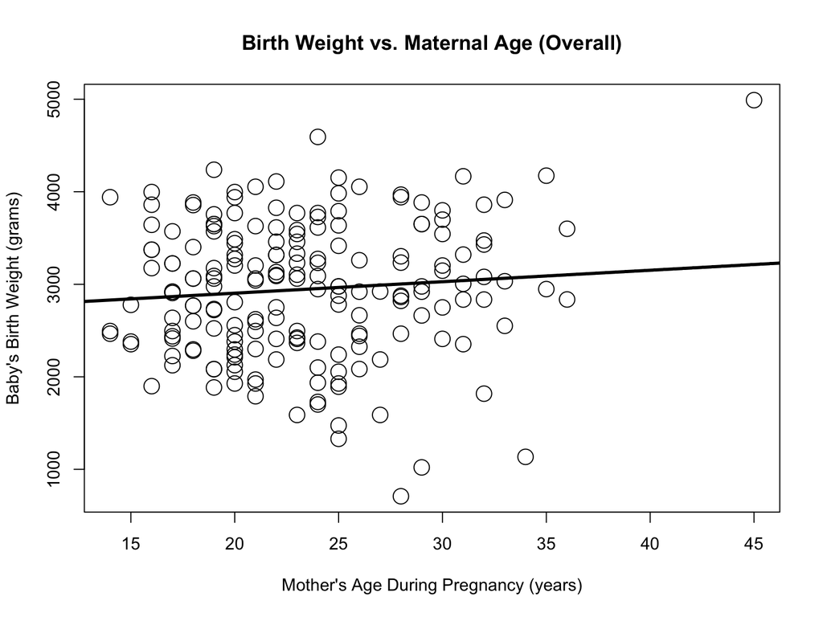

```r
# Scatterplot with fitted regression line
plot(bwdata$age, bwdata$bwt,
     xlab = 'Mother\'s Age During Pregnancy (years)',
     ylab = 'Baby\'s Birth Weight (grams)',
     cex = 2,
     main = 'Birth Weight vs. Maternal Age (Overall)')
abline(fit1, lwd = 3)
```

**Visual Interpretation**

- **Scatter:** Shows variability in birth weight at each age
- **Line slope:** Direction and strength of the association
- **Clinical check:** Does the relationship look linear? Any outliers?

## 2.6 Question 3: Does Smoking Modify the Age-Birth Weight Relationship?

Test for interaction by including a product term (`age × smoke`).

```r
# Regression with interaction term
fit2 <- lm(bwt ~ age + smoke + age*smoke, data = bwdata)
summary(fit2)
```

```
Call:
lm(formula = bwt ~ age + smoke + age * smoke, data = bwdata)

Residuals:
     Min       1Q   Median       3Q      Max
-2189.27  -458.46    51.46   527.26  1521.39

Coefficients:
            Estimate Std. Error t value Pr(>|t|)
(Intercept)  2406.06     292.19   8.235 3.18e-14 ***
age            27.73      12.15   2.283   0.0236 *
smoke         798.17     484.34   1.648   0.1011
age:smoke     -46.57      20.45  -2.278   0.0239 *
---
Signif. codes:  0 '***' 0.001 '**' 0.01 '*' 0.05 '.' 0.1 ' ' 1

Residual standard error: 709.3 on 185 degrees of freedom
Multiple R-squared:  0.06909,   Adjusted R-squared:  0.054
F-statistic: 4.577 on 3 and 185 DF,  p-value: 0.004068
```

**Interpreting the Interaction**

**Key coefficient:** `age:smoke` (the interaction term)

- **If p < 0.05:** The effect of maternal age on birth weight differs significantly between smokers and non-smokers
- **If p ≥ 0.05:** No strong evidence of effect modification by smoking

**Clinical interpretation:** If significant, maternal age affects birth weight differently in mothers who smoke vs those who do not. We should report age-specific slopes for each smoking group.

## 2.7 Question 4: Visualize Effect Modification

Create separate regression lines for smokers and non-smokers to show how the relationship differs.

```r
# Subset by smoking status
smoker    <- subset(bwdata, smoke == 1)
nonsmoker <- subset(bwdata, smoke == 0)
```

```r
# Regression among smokers
fit3 <- lm(bwt ~ age, data = smoker)
summary(fit3)
```

```
Call:
lm(formula = bwt ~ age, data = smoker)

Residuals:
    Min      1Q  Median      3Q     Max
-1967.7  -464.1    13.6   498.8  1391.7

Coefficients:
            Estimate Std. Error t value Pr(>|t|)
(Intercept)  3204.23     357.96   8.951 2.57e-13 ***
age           -18.84      15.24  -1.236     0.22
---
Signif. codes:  0 '***' 0.001 '**' 0.01 '*' 0.05 '.' 0.1 ' ' 1

Residual standard error: 657.3 on 72 degrees of freedom
Multiple R-squared:  0.02078,   Adjusted R-squared:  0.007183
F-statistic: 1.528 on 1 and 72 DF,  p-value: 0.2204
```

```r
confint(fit3)
```

```
                 2.5 %     97.5 %
(Intercept) 2490.64656 3917.81914
age          -49.22246   11.54138
```

**Interpretation (Smokers)**

- **Slope (age):** Change in birth weight per 1-year increase in maternal age **among mothers who smoke**

```r
# Regression among non-smokers
fit4 <- lm(bwt ~ age, data = nonsmoker)
summary(fit4)
```

```
Call:
lm(formula = bwt ~ age, data = nonsmoker)

Residuals:
     Min       1Q   Median       3Q      Max
-2189.27  -449.75    73.58   542.25  1521.39

Coefficients:
            Estimate Std. Error t value Pr(>|t|)
(Intercept)  2406.06     305.05   7.887 2.14e-12 ***
age            27.73      12.68   2.186   0.0309 *
---
Signif. codes:  0 '***' 0.001 '**' 0.01 '*' 0.05 '.' 0.1 ' ' 1

Residual standard error: 740.5 on 113 degrees of freedom
Multiple R-squared:  0.04058,   Adjusted R-squared:  0.03209
F-statistic:  4.78 on 1 and 113 DF,  p-value: 0.03085
```

```r
confint(fit4)
```

```
                  2.5 %     97.5 %
(Intercept) 1801.691173 3010.42478
age            2.602105   52.86065
```

**Interpretation (Non-Smokers)**

- **Slope (age):** Change in birth weight per 1-year increase in maternal age **among mothers who do not smoke**
- **Compare slopes:** Are they similar or different?

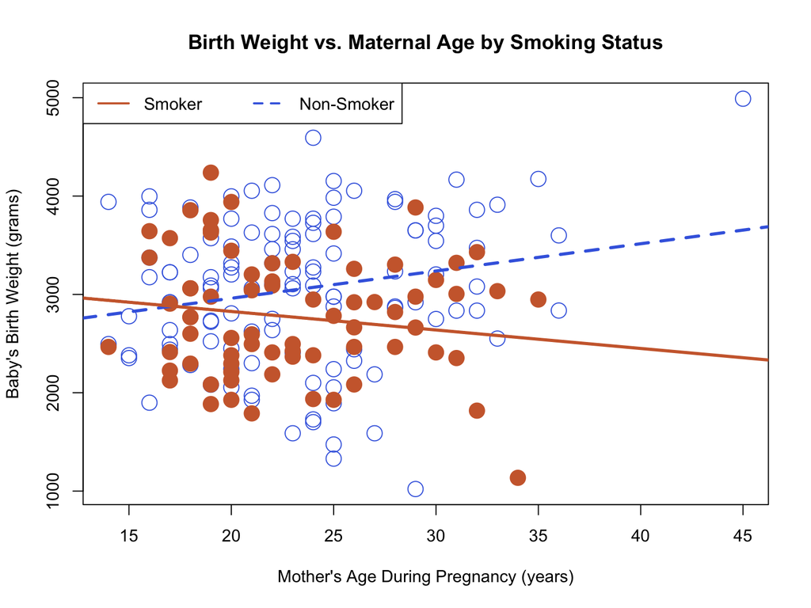

```r
# Scatterplot with separate lines for smokers and non-smokers
plot(nonsmoker$age, nonsmoker$bwt,
     xlab = 'Mother\'s Age During Pregnancy (years)',
     ylab = 'Baby\'s Birth Weight (grams)',
     col = 'royalblue', cex = 2,
     main = 'Birth Weight vs. Maternal Age by Smoking Status')
points(smoker$age, smoker$bwt,
       col = 'sienna3', pch = 19, cex = 2)
abline(fit4, col = 'royalblue', lty = 2, lwd = 3)
abline(fit3, col = 'sienna3', lwd = 3)
legend('topleft', c('Smoker', 'Non-Smoker'),
       col = c('sienna3', 'royalblue'),
       lty = c(1, 2), lwd = 2, horiz = TRUE)
```

**Visual Interpretation**

- **Different slopes:** Evidence of interaction (effect modification)
- **Parallel lines:** No interaction (same age effect in both groups)

**Clinical example:** If the slope is steeper in non-smokers, older non-smoking mothers have heavier babies, but this benefit is reduced or absent in mothers who smoke. Smoking may blunt the positive effect of maternal age on fetal growth.

# Summary and Key Takeaways

## 2.8 What is Interaction?

**Key Points**

- **Interaction (effect modification):** The effect of one variable on an outcome depends on the level of another variable
- **Example:** Smoking’s effect on lung function differs by age; maternal age’s effect on birth weight differs by smoking status
- **Why it matters:** Pooled (average) effects can mask important subgroup differences

## 2.9 How to Detect Interaction

**Key Points**

1. **Stratified analysis:** Fit separate models in each subgroup and compare effect estimates
2. **Regression with interaction term:** Include a product term (X × Z); test if the coefficient is significant (p < 0.05)
3. **Visualization:** Plot the relationship for each subgroup; look for different slopes

**Rule of thumb:** If the interaction term is significant, report stratified results. Do not rely on the pooled estimate.

## 2.10 Clinical Interpretation

**Key Points**

**Example 1: FEV1 and Smoking in COPD**

- Smoking’s impact on lung function is much larger in older patients (~1.02 L) than younger patients (~0.36 L)
- **Clinical implication:** Smoking cessation is especially critical for older COPD patients

**Example 2: Birth Weight and Maternal Age**

- The effect of maternal age on birth weight may differ by smoking status
- **Clinical implication:** Smoking may reduce the benefit of older maternal age on fetal growth. Smoking cessation during pregnancy is vital.

## 2.11 When to Report Interaction

**Best Practices**

- **Always test for interaction** when you have a plausible effect modifier
- **If interaction is significant (p < 0.05):**
  - Report stratified results (group-specific effects)
  - Visualize with separate lines or subgroup analyses
  - Discuss clinical implications (which patients benefit most?)
- **If interaction is not significant:**
  - Report the main effect (pooled estimate)
  - Mention that you tested for interaction and found no evidence
- **Consider biological plausibility:** Not all statistical interactions are clinically meaningful. Use clinical knowledge to interpret findings.

# Glossary

- **Interaction (Effect Modification):** When the effect of one variable on an outcome depends on the level of another variable.
- **Stratified Analysis:** Analyzing the relationship separately within levels of a third variable (e.g., age groups, smoking status).
- **Interaction Term:** A product of two variables (e.g., X × Z) included in a regression model to test for interaction.
- **Main Effect:** The effect of a variable on the outcome, averaged across levels of other variables (ignoring interaction).
- **Subgroup Analysis:** Examining effects within specific patient subgroups to identify who benefits most (or least) from an exposure or treatment.